# Tugas Besar IF2220 - Probabilitas dan Statistika

### e. Bagian awal kolom Sulfate memiliki variansi yang sama dengan bagian akhirnya?

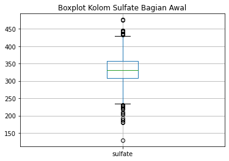

```python
# Boxplot data kolom Sulfate bagian awal kolom

df[:1005].boxplot(["sulfate"])
plt.title("Boxplot Kolom Sulfate Bagian Awal")
plt.show()
```

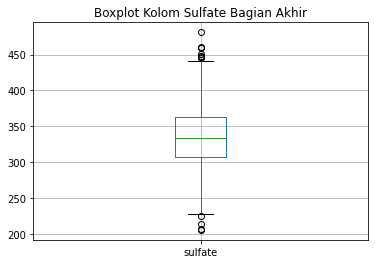

```python
# Boxplot data kolom Sulfate bagian akhir kolom

df[1005:].boxplot(["sulfate"])
plt.title("Boxplot Kolom Sulfate Bagian Akhir")
plt.show()
```

$\sigma^2_{1}$ = variansi kolom Sulfate bagian awal

$\sigma^2_{2}$ = variansi kolom Sulfate bagian akhir

Enam langkah testing:

Penentuan daerah kritis, yaitu:

$f < f_{1-\alpha/2}(v_{1},v_{2})$ atau $f > f_{\alpha/2}(v_{1},v_{2})$

dengan $v_{1} = n_{1} - 1$ dan $v_{2} = n_{2} - 1$

$v_{1} = 1005 - 1 = 1004 $

$v_{2} = 1005 - 1 = 1004 $

```python
# penentuan daerah kritis menggunakan library scipy

upper = s.f.ppf(1 - 0.05/2, 1005 - 1, 1005 - 1)
lower = s.f.ppf(0.05/2, 1005 - 1, 1005 - 1)

print("Nilai batas bawah daerah kritis = " + str(lower))
print("Nilai batas atas daerah kritis = " + str(upper))
```

```
Nilai batas bawah daerah kritis = 0.883572344355818
Nilai batas atas daerah kritis = 1.1317692392568777
```

Didapatkan daerah kritis sebagai berikut:

f < 0.883572344355818 atau f > 1.1317692392568777

1. Perhitungan nilai uji statistik dan p-value:

```python
var1 = df[:1005]["sulfate"].var()
var2 = df[1005:]["sulfate"].var()

f = var1 / var2
print("Nilai uji statistik (f) = " + str(f))

# Perhitungan p-value

'''
    Perhitungan p-value dilakukan dengan bantuan library scipy untuk menghitung
    fungsi distribusi kumulatif
'''

pVal = 2*(1-s.norm.cdf(abs(f)))
print("Nilai p-value = " + str(pVal))
```

```
Nilai uji statistik (f) = 1.0152511043950063
Nilai p-value = 0.30998614559492665
```

1. Pengambilan keputusan

Berdasarkan nilai uji statistik, yaitu 1.0152511043950063 yang berada di luar daerah kritis, diambil keputusan bahwa $H_0$ diterima. Selain itu, didapatkan nilai p-value sebesar 0.30998614559492665 yang lebih besar dari nilai alpha, yaitu 0.05. Oleh karena itu, juga diambil keputusan bahwa $H_0$ diterima. Dengan kata lain, variansi kolom Sulfate bagian awal sama dengan variansi kolom Sulfate bagian akhir.

# Nomor 6

Test korelasi: tentukan apakah setiap kolom non-target berkorelasi dengan kolom target, dengan menggambarkan juga scatter plot nya. Gunakan correlation test!

Tes korelasi yang dilakukan menggunakan bantuan fungsi pearsonr dari library scipy yang berdasarkan Person Correlation Coefficient atau Koefisien Korelasi Pearson.

```python
def correlation(column1, column2):
    cor, pVal = s.pearsonr(df[column1], df[column2])
    sns.regplot(x = df[column1], y = df[column2])
    print("Nilai korelasi antara kolom " + column1 + " dan " + column2 + " sebesar " + str(cor))
```

### Kolom pH dan potability

```
Nilai korelasi antara kolom pH dan potability sebesar 0.015475094408433499
```

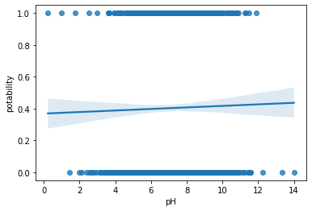

```python
correlation("pH", "potability")
```

Nilai korelasi antara kolom pH dan potability sebesar 0.015475094408433499 lebih besar dari nol. Artinya, kolom pH dan potability berkorelasi secara positif atau berbanding lurus. Hal itu juga terlihat dari grafik regresi yang memiliki gradien positif.

### Kolom hardness dan potability

```
Nilai korelasi antara kolom hardness dan potability sebesar -0.0014631528959479546
```

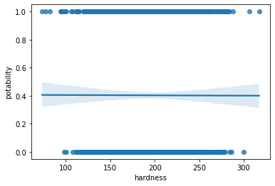

```python
correlation("hardness", "potability")
```

### Kolom solids dan potability

```
Nilai korelasi antara kolom solids dan potability sebesar 0.03897657818173474
```

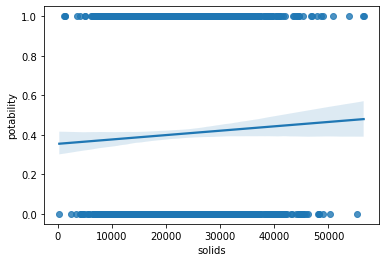

```python
correlation("solids", "potability")
```

Nilai korelasi antara kolom solids dan potability sebesar 0.03897657818173474 lebih besar dari nol. Artinya, kolom solids dan potability berkorelasi secara positif atau berbanding lurus. Hal itu juga terlihat dari grafik regresi yang memiliki gradien positif.

### Kolom chloramines dan potability

```
Nilai korelasi antara kolom chloramines dan potability sebesar 0.020778921840524135
```

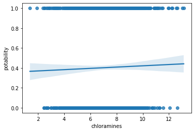

```python
correlation("chloramines", "potability")
```

Nilai korelasi antara kolom chloramines dan potability sebesar 0.020778921840524135 lebih besar dari nol. Artinya, kolom chloramines dan potability berkorelasi secara positif atau berbanding lurus. Hal itu juga terlihat dari grafik regresi yang memiliki gradien positif.

### Kolom sulfate dan potability

```
Nilai korelasi antara kolom sulfate dan potability sebesar -0.01570316441927381
```

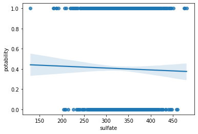

```python
correlation("sulfate", "potability")
```

Nilai korelasi antara kolom sulfate dan potability sebesar -0.01570316441927381 lebih kecil dari nol. Artinya, kolom sulfate dan potability berkorelasi secara negatif atau berbanding terbalik. Hal itu juga terlihat dari grafik regresi yang memiliki gradien negatif.

### Kolom conductivity dan potability

```
Nilai korelasi antara kolom conductivity dan potability sebesar -0.01625712011137709
```

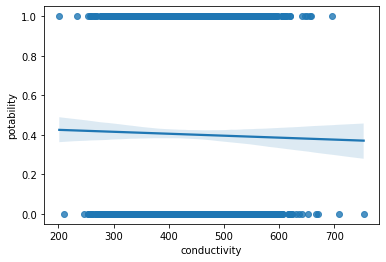

```python
correlation("conductivity", "potability")
```

Nilai korelasi antara kolom conductivity dan potability sebesar -0.01625712011137709 lebih kecil dari nol. Artinya, kolom conductivity dan potability berkorelasi secara negatif atau berbanding terbalik. Hal itu juga terlihat dari grafik regresi yang memiliki gradien negatif.

### Kolom organic carbon dan potability

```
Nilai korelasi antara kolom organicCarbon dan potability sebesar -0.015488461910747308
```

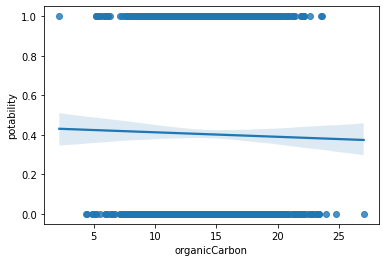

```python
correlation("organicCarbon", "potability")
```

Nilai korelasi antara kolom OrganicCarbon dan potability sebesar -0.015488461910747308 lebih kecil dari nol. Artinya, kolom OrganicCarbon dan potability berkorelasi secara negatif atau berbanding terbalik. Hal itu juga terlihat dari grafik regresi yang memiliki gradien negatif.

### Kolom trihalomethanes dan potability

```
Nilai korelasi antara kolom trihalomethanes dan potability sebesar 0.009236711064713032
```

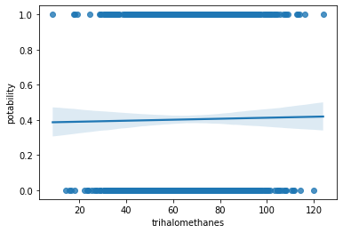

```python
correlation("trihalomethanes", "potability")
```

Nilai korelasi antara kolom trihalomethanes dan potability sebesar 0.009236711064713032 lebih besar dari nol. Artinya, kolom trihalomethanes dan potability berkorelasi secara positif atau berbanding lurus. Hal itu juga terlihat dari grafik regresi yang memiliki gradien positif.

### Kolom turbidity dan potability

```
Nilai korelasi antara kolom turbidity dan potability sebesar 0.0223310426406227
```

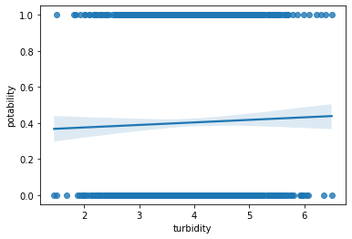

```python
correlation("turbidity", "potability")
```

Nilai korelasi antara kolom turbidity dan potability sebesar 0.0223310426406227 lebih besar dari nol. Artinya, kolom turbidity dan potability berkorelasi secara positif atau berbanding lurus. Hal itu juga terlihat dari grafik regresi yang memiliki gradien positif.